# Support VEctor Machine:

### Terminologies:

- **Margin**
- **Maxumum Margin Classifier**
- **Misclassfication by allowing sensiivity**
- **Bias Variance Trade-off**

  The bias–variance dilemma or bias–variance problem is the conflict in trying to simultaneously minimize these two sources of error that prevent supervised learning algorithms from generalizing beyond their training set.
  - The bias error is an error from erroneous assumptions in the learning algorithm. High bias can cause an algorithm to miss the relevant relations between features and target outputs (underfitting).
  - The variance is an error from sensitivity to small fluctuations in the training set. High variance may result from an algorithm modeling the random noise in the training data (overfitting).
  - High-variance learning methods may be able to represent their training set well but are at risk of overfitting to noisy or unrepresentative training data.
  - In contrast, algorithms with high bias typically produce simpler models that may fail to capture important regularities (i.e. underfit) in the data.
- Soft Margin
- Cross Validation

### **Kernel Functions:**

#### **Polynomial Kernel:**

[figure not shown]

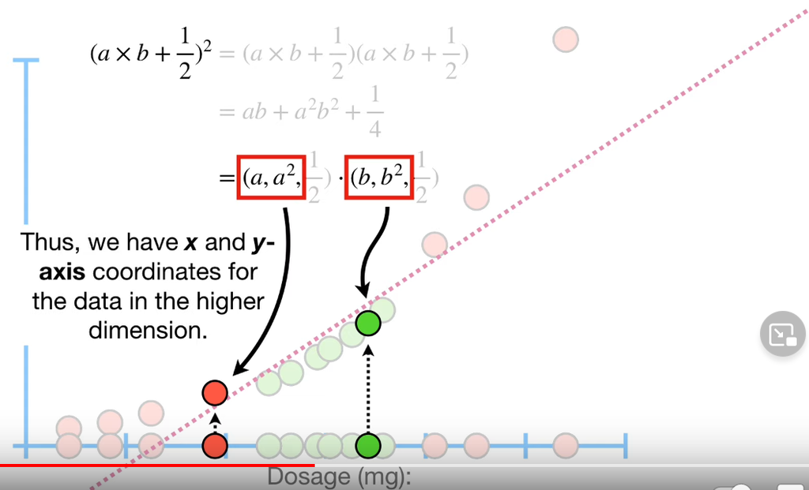

```
    * a, b are the two data points,
    * r is a constant
    * d is the degreee of polynomials
    * r, d are determnied by cross validation
```

#### Radial Basis Kernel

- Radial Basis Function calculates the relationship between two points in a infinite dimension

```python
pwd
```